# Prologue

# Hypothesis Testing

Dr. Iris now turns her attention to hypothesis testing to explore relationships and make statistical inferences from the data. She identifies several hypotheses to test, using different statistical methods

## Null Hypothesis 1: Patients with one disease are more likely to have other diseases

In order to test this hypothesis, Dr. Iris wants to study only those patients, who have 2 or more dieseases at the same time.  
She creates a new column indicating the amount of diseases for a patient

```python
cleaned_df['num_diseases'] = cleaned_df.iloc[:, 7:15].sum(axis=1)
multiple_diseases_df = cleaned_df[cleaned_df['num_diseases'] > 1]
multiple_diseases_df.head(3)
```

|  | ID | Patient Age | Patient Sex | Left-Fundus | Right-Fundus | Left-Diagnostic Keywords | Right-Diagnostic Keywords | Normal | Diabetes | Glaucoma | ... | Hypertension | Myopia | Other | filepath | labels | target | filename | left-diagnostic-category | right-diagnostic-category | num_diseases |
| --- | --- | --- | --- | --- | --- | --- | --- | --- | --- | --- | --- | --- | --- | --- | --- | --- | --- | --- | --- | --- | --- |
| 2 | 2 | 42 | 0 | 2_left.jpg | 2_right.jpg | laser spot，moderate non proliferative retinopathy | moderate non proliferative retinopathy | 0 | 1 | 0 | ... | 0 | 0 | 1 | ../input/ocular-disease-recognition-odir5k/ODI... | [D] | [0, 1, 0, 0, 0, 0, 0, 0] | 2_right.jpg | moderate | moderate | 2 |
| 3 | 4 | 53 | 0 | 4_left.jpg | 4_right.jpg | macular epiretinal membrane | mild nonproliferative retinopathy | 0 | 1 | 0 | ... | 0 | 0 | 1 | ../input/ocular-disease-recognition-odir5k/ODI... | [D] | [0, 1, 0, 0, 0, 0, 0, 0] | 4_right.jpg | none | mild | 2 |
| 5 | 6 | 60 | 0 | 6_left.jpg | 6_right.jpg | macular epiretinal membrane | moderate non proliferative retinopathy，epireti... | 0 | 1 | 0 | ... | 0 | 0 | 1 | ../input/ocular-disease-recognition-odir5k/ODI... | [D] | [0, 1, 0, 0, 0, 0, 0, 0] | 6_right.jpg | none | moderate | 2 |

3 rows × 22 columns

Now Dr. Iris builds a **comorbidity matrix** to track how often different diseases co-occur in patients with multiple diagnoses. For each patient, she checks which diseases they have and updates the matrix, increasing the count whenever two diseases co-occur.

This matrix will help her understand patterns of disease combinations and identify common comorbidities among ocular conditions

```python
disease_columns = ['Diabetes', 'Glaucoma', 'Cataract', 'Age Degeneration', 'Hypertension', 'Myopia', 'Other']
comorbidity_matrix = pd.DataFrame(0, index=disease_columns, columns=disease_columns)

for index, row in multiple_diseases_df.iterrows():
    patient_diseases = row[disease_columns].index[row[disease_columns] > 0]
    for disease1 in patient_diseases:
        for disease2 in patient_diseases:
            if disease1 != disease2:
                comorbidity_matrix.at[disease1, disease2] += 1
```

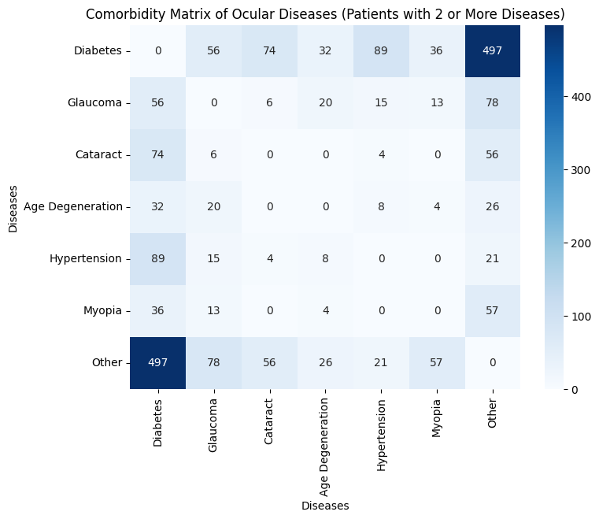

```python
plt.figure(figsize=(8, 6))
sns.heatmap(comorbidity_matrix, annot=True, fmt='d', cmap='Blues')
plt.title('Comorbidity Matrix of Ocular Diseases (Patients with 2 or More Diseases)')
plt.xlabel('Diseases')
plt.ylabel('Diseases')
plt.show()
```

#### Interpretation

Dr. Iris sees that the diagonal of the comorbidity matrix represents patients with only one disease. Since she is analyzing multiple diseases, the diagonal values are set to zero to focus solely on co-occurring conditions.

What may this imply?

Dr. **Iris** makes the following observations from the comorbidity matrix:

1. **Diabetes as a Central Disease**:  
   **Diabetes** frequently co-occurs with other diseases, which suggests that it might be a primary condition in the dataset that leads to additional diagnoses
2. **High Comorbidity with "Other Diseases"**:  
   Several diseases show high comorbidity with the **"Other diseases"** category, which may be an indicator of a variety of conditions grouped here, which needs deeper investigation.

### Next Step: Testing the Hypothesis with a Chi-Square Test

Dr. Iris will now use a **chi-square test** to statistically confirm if the comorbidities she observed are significant. She uses the chi-square test because it is ideal for testing relationships between categorical variables, like the presence or absence of diseases

```python
def perform_chi2_test(multiple_diseases_df):
    results = {}
    total_patients = multiple_diseases_df.shape[0]

    for disease1 in disease_columns:
        for disease2 in disease_columns:
            if disease1 != disease2:
                both_diseases = multiple_diseases_df[
                    (multiple_diseases_df[disease1] > 0) & (multiple_diseases_df[disease2] > 0)
                ].shape[0]

                only_disease1 = multiple_diseases_df[
                    (multiple_diseases_df[disease1] > 0) & (multiple_diseases_df[disease2] == 0)
                ].shape[0]

                only_disease2 = multiple_diseases_df[
                    (multiple_diseases_df[disease2] > 0) & (multiple_diseases_df[disease1] == 0)
                ].shape[0]

                neither_disease = total_patients - (both_diseases + only_disease1 + only_disease2)

                contingency_table = [
                    [both_diseases, only_disease2],
                    [only_disease1, neither_disease]
                ]


                if any(count < 0 for count in contingency_table[0]) or any(count < 0 for count in contingency_table[1]):
                    continue
                if any(value == 0 for row in contingency_table for value in row):
                    continue

                chi2, p, _, _ = chi2_contingency(contingency_table)
                results[(disease1, disease2)] = p

    return results


chi2_results = perform_chi2_test(multiple_diseases_df)
significant_results = {k: v for k, v in chi2_results.items() if v > 0.05}

non_symmetrical_results = []
seen_pairs = set()

for (disease1, disease2), p_value in significant_results.items():
  pair = tuple(sorted((disease1, disease2)))
  if pair not in seen_pairs:
    non_symmetrical_results.append((disease1, disease2))
    seen_pairs.add(pair)

for diseases in non_symmetrical_results:
    p_value = significant_results[diseases]
    if p_value > 0.05:
        print(f"There is significant association found between {diseases}, p-value is {p_value:.2f}")
```

```
There is significant association found between ('Diabetes', 'Hypertension'), p-value is 0.07
There is significant association found between ('Glaucoma', 'Age Degeneration'), p-value is 0.09
There is significant association found between ('Glaucoma', 'Hypertension'), p-value is 0.12
There is significant association found between ('Glaucoma', 'Myopia'), p-value is 0.42
There is significant association found between ('Age Degeneration', 'Hypertension'), p-value is 0.38
There is significant association found between ('Age Degeneration', 'Myopia'), p-value is 0.14
```

### Chi-square test results interpretation:

Dr. Iris now creates a heatmap to visualize the p-values from the chi-square test to different conditions

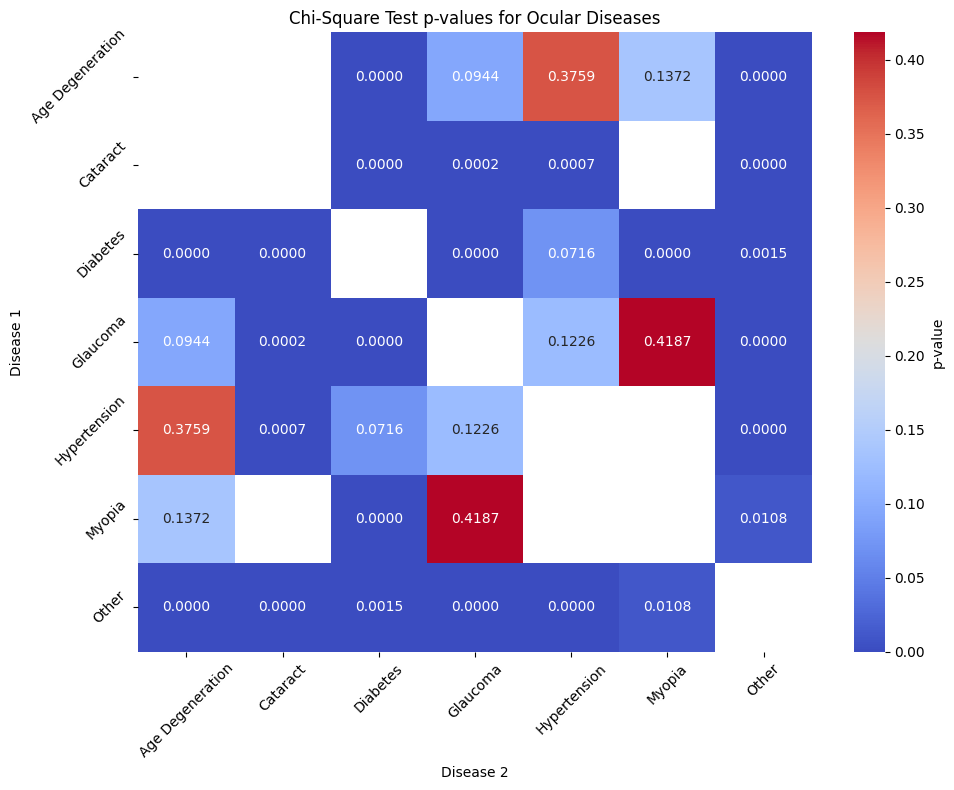

```python
results_df = pd.DataFrame.from_dict(chi2_results, orient='index', columns=['p-value'])
results_df.index = pd.MultiIndex.from_tuples(results_df.index, names=['Disease 1', 'Disease 2'])
results_df = results_df.reset_index()

heatmap_data = results_df.pivot(index="Disease 1", columns="Disease 2", values="p-value")

plt.figure(figsize=(10, 8))
sns.heatmap(heatmap_data, annot=True, fmt=".4f", cmap="coolwarm", cbar_kws={'label': 'p-value'})
plt.title('Chi-Square Test p-values for Ocular Diseases')
plt.xlabel('Disease 2')
plt.ylabel('Disease 1')
plt.xticks(rotation=45)
plt.yticks(rotation=45)
plt.tight_layout()
plt.show();
```

## Null Hypothesis 2: There's no significant age difference between patients with and without diabetes

So, Dr. Iris observes that **Diabetes** is the most common condition among the diseases in her dataset. To investigate whether **Diabetes is associated with age**, she formulates a hypothesis to determine if there is a significant difference in the average age between patients with and without diabetes.

She uses a **t-test**, which is well-suited for comparing the means of **two independent groups**—in this case, the ages of patients with and without diabetes. Since age is a **continuous variable** and diabetes presence creates two distinct groups, the t-test will help Dr. Iris identify whether any observed age differences are statistically significant or just due to random variation

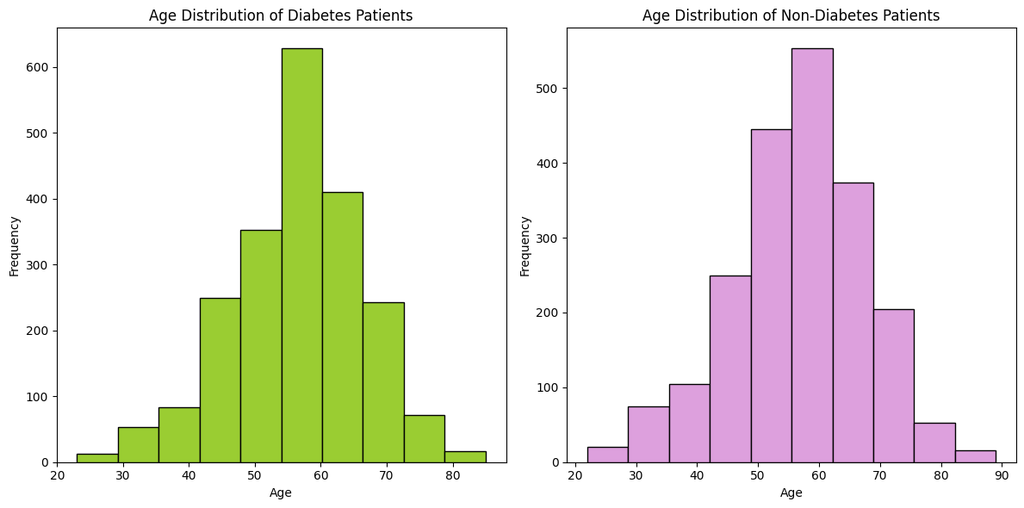

```python
diabetes_age = cleaned_df[cleaned_df['Diabetes'] == 1]['Patient Age']
non_diabetes_age = cleaned_df[cleaned_df['Normal'] == 1]['Patient Age']  # Using 'N' for normal fundus

plt.figure(figsize=(12, 6))

plt.subplot(1, 2, 1)
plt.hist(diabetes_age, bins=10, color="yellowgreen", edgecolor="black")
plt.xlabel("Age")
plt.ylabel("Frequency")
plt.title("Age Distribution of Diabetes Patients")

plt.subplot(1, 2, 2)
plt.hist(non_diabetes_age, bins=10, color="plum", edgecolor="black")
plt.xlabel("Age")
plt.ylabel("Frequency")
plt.title("Age Distribution of Non-Diabetes Patients")

plt.tight_layout()
plt.show()
```

```
Hypothesis 1 Results:
T-statistic:  -1.3579535437826737
P-value:  0.17455116316550867
```

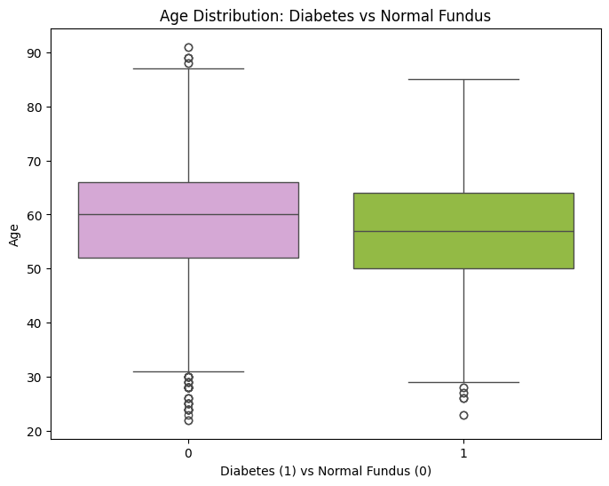

```python
t_stat, p_value = stats.ttest_ind(diabetes_age, non_diabetes_age)
print("Hypothesis 1 Results:")
print("T-statistic: ", t_stat)
print("P-value: ",p_value)

plt.figure(figsize=(8, 6))
colors = ['plum', 'yellowgreen']
sns.boxplot(x='Diabetes', y='Patient Age', data=cleaned_df, palette=colors)
plt.title('Age Distribution: Diabetes vs Normal Fundus')
plt.xlabel('Diabetes (1) vs Normal Fundus (0)')
plt.ylabel('Age')
plt.show()
```

### Hypothesis 2 Conclusions:

- **T-statistic**: -1.36
- **P-value**: 0.17455
1. **T-statistic**: The negative t-statistic suggests that the average age of patients with diabetes might be slightly lower than those without diabetes, but the difference is minimal
2. **P-value**: With a p-value of **0.17455**, which is **greater than the 0.05 significance threshold**, Dr. Iris **fails to reject the null hypothesis**. This means there is **no statistically significant difference** in the average age between patients with and without diabetes

The t-test results suggest that **age does not significantly differ** between those with and without diabetes. Therefore, **diabetes does not appear to be strongly associated with age** in this dataset, meaning that any age differences between the groups are likely due to random variation rather than an effect of diabetes

## Null Hypothesis 3: There's no correlation between age and the number of ocular diseases

Dr. Iris now explores the relationship between a patient's **age** and the **number of ocular diseases** they have. Using **Pearson correlation**, she tests the **linear relationship** between these two continuous variables

This analysis helps her understand if older patients are more likely to have multiple eye conditions. The Pearson correlation provides a **quantitative measure** of the relationship, along with a **statistical significance** test to determine if the result is meaningful or due to chance

```
Hypothesis 2 Results:
Correlation coefficient:  0.09720903965632197
P-value:  8.126144414985553e-15
```

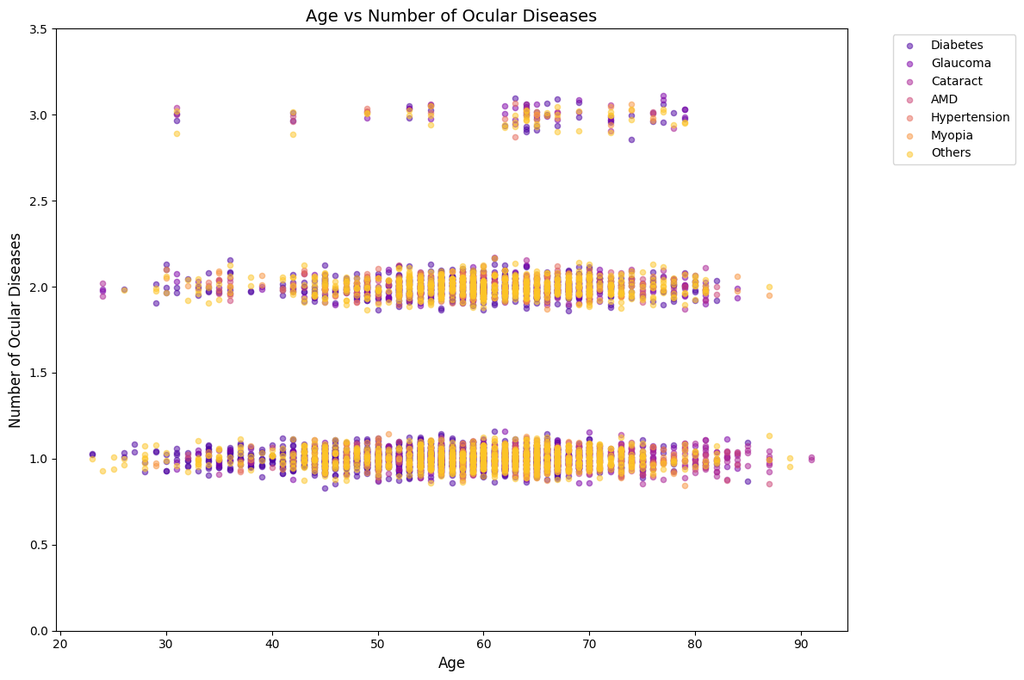

```python
diseases = ['Diabetes', 'Glaucoma', 'Cataract', 'Age Degeneration', 'Hypertension', 'Myopia', 'Other']
disease_names = ['Diabetes', 'Glaucoma', 'Cataract', 'AMD', 'Hypertension', 'Myopia', 'Others']

cleaned_df['Total Diseases'] = cleaned_df[diseases].sum(axis=1)
correlation, p_value = stats.pearsonr(cleaned_df['Patient Age'], cleaned_df['Total Diseases'])
print("\nHypothesis 2 Results:")
print("Correlation coefficient: ", correlation)
print(f"P-value: ", p_value)

color_palette = sns.color_palette("plasma", len(diseases))
color_map = dict(zip(diseases, color_palette))

plt.figure(figsize=(12, 8))
for disease in diseases:
    disease_df = cleaned_df[cleaned_df[disease] == 1]
    y_jitter = np.random.normal(0, 0.05, len(disease_df))
    plt.scatter(disease_df['Patient Age'], disease_df['Total Diseases'] + y_jitter,
                label=disease, color=color_map[disease], alpha=0.5, s=20)

plt.xlabel('Age', fontsize=12)
plt.ylabel('Number of Ocular Diseases', fontsize=12)
plt.title('Age vs Number of Ocular Diseases', fontsize=14)
plt.legend(labels=disease_names, bbox_to_anchor=(1.05, 1), loc='upper left')
plt.ylim(0, cleaned_df['Total Diseases'].max() + 0.5)
plt.tight_layout()
plt.show()
```

### Hypothesis 3 Conclusions:

1. A very slight but positive correlation is indicated by the correlation coefficient of 0.097209. Since the p-value is so tiny in relation to the significance level (0.05 or 0.1), we reject the null hypothesis
2. The number of ocular diseases and age have a statistically significant correlation. Given that there is a slight tendency for the number to increase with age, this relationship is positive
3. The coefficient, however, is weak, indicating that a person's age is not a reliable indicator of how many ocular diseases they may have. For a more thorough understanding of the occurrence of ocular diseases, more research into other variables and potentially non-linear relationships would be helpful

Dr. Iris recognizes that while **age** is a key factor in ocular health, **gender** may also influence the prevalence of eye conditions. To explore this, she visualizes the **distribution of genders** across various ocular diseases to see if certain conditions are more common in one gender than the other

By analyzing the **gender breakdown** for each disease, Dr. Iris aims to identify potential patterns and trends, helping her understand whether men or women are more likely to be affected by specific eye conditions

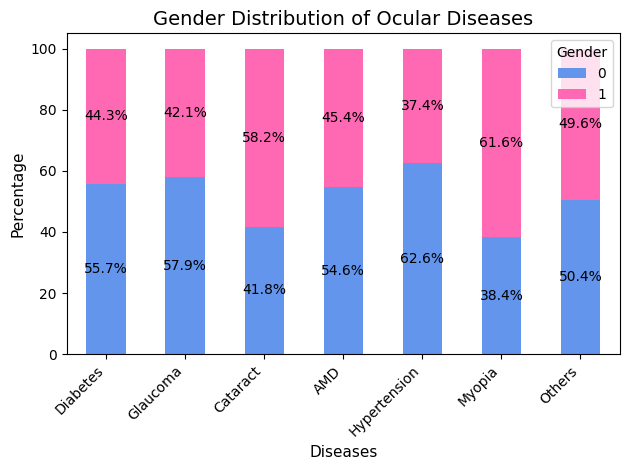

```
Counts:
                     0    1
Diabetes          1181  938
Glaucoma           230  167
Cataract           168  234
Age Degeneration   173  144
Hypertension       127   76
Myopia             108  173
Other              799  787

Percentages:
                          0          1
Diabetes          55.733837  44.266163
Glaucoma          57.934509  42.065491
Cataract          41.791045  58.208955
Age Degeneration  54.574132  45.425868
Hypertension      62.561576  37.438424
Myopia            38.434164  61.565836
Other             50.378310  49.621690
```

```python
gender_counts = {disease: [] for disease in diseases}
for disease in diseases:
    male_count = cleaned_df[(cleaned_df[disease] == 1) & (cleaned_df['Patient Sex'] == 0)].shape[0]
    female_count = cleaned_df[(cleaned_df[disease] == 1) & (cleaned_df['Patient Sex'] == 1)].shape[0]
    gender_counts[disease] = [male_count, female_count]
gender_df = pd.DataFrame(gender_counts, index=[0, 1]).T
gender_df_percentage = gender_df.div(gender_df.sum(axis=1), axis=0) * 100

plt.figure(figsize=(10, 8))
color_map = {0: 'cornflowerblue', 1: 'hotpink'}
ax = gender_df_percentage.plot(kind='bar', stacked=True, color=[color_map[0], color_map[1]])
plt.title('Gender Distribution of Ocular Diseases', fontsize=14)
plt.xlabel('Diseases', fontsize=11)
plt.ylabel('Percentage', fontsize=11)
plt.legend(title='Gender', loc='upper right')
plt.xticks(range(len(diseases)), disease_names, rotation=45, ha='right')
for c in ax.containers:
    ax.bar_label(c, fmt='%.1f%%', label_type='center')
plt.tight_layout()
plt.show()

print("Counts:")
print(gender_df)
print("\nPercentages:")
print(gender_df_percentage)
```

Dr. Iris notices that the prior analysis does not clearly indicate which gender is more likely to suffer from any specific ocular disease. Given existing research that suggests certain types of **glaucoma**, like **angle-closure glaucoma**, are more common in women, she decides to focus on **glaucoma** to investigate this further

## Null Hypothesis 4: There is no significant association between gender and the incidence of glaucoma

Dr. Iris chooses to use a **chi-squared test** for this analysis because it is well-suited for her **categorical data** (gender and glaucoma status)

This test provides a **clear and interpretable result**, ideal for medical research, where **statistical accuracy** is crucial

```
Glaucoma        0    1
Patient Sex
0            3188  230
1            2769  167

Hypothesis 3 Results:
Chi-square statistic:  2.747224564278787
P-value:  0.09742340676309791
```

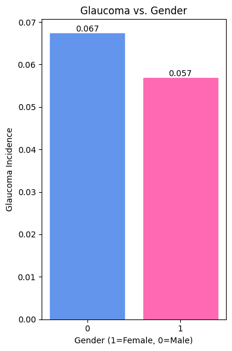

```python
gender_glaucoma = pd.crosstab(cleaned_df['Patient Sex'], cleaned_df['Glaucoma'])
print(gender_glaucoma)
chi2, p_value, dof, expected = stats.chi2_contingency(gender_glaucoma)

print("\nHypothesis 3 Results:")
print("Chi-square statistic: ", chi2)
print("P-value: ", p_value)
grouped_data = cleaned_df.groupby('Patient Sex')['Glaucoma'].mean().reset_index()
plt.figure(figsize=(4, 6))
color_map = {0: 'cornflowerblue', 1: 'hotpink'}
bars = plt.bar(grouped_data['Patient Sex'], grouped_data['Glaucoma'])
for bar, gender in zip(bars, grouped_data['Patient Sex']):
    bar.set_color(color_map[gender])
plt.title('Glaucoma vs. Gender')
plt.xlabel('Gender (1=Female, 0=Male)')
plt.ylabel('Glaucoma Incidence')
plt.xticks(df['Patient Sex'].unique())

for bar in bars:
    height = bar.get_height()
    plt.text(bar.get_x() + bar.get_width()/2., height,
             f'{height:.3f}',
             ha='center', va='bottom')
plt.tight_layout()
plt.show()
```

### Hypothesis 4 Conclusions:

Dr. Iris recognizes the need for further research to investigate the potential gender differences in glaucoma incidence more robustly

# Overall EDA Conclusion:

During her EDA, Dr. Iris's had several key findings, which included:

EDA uncoveres important trends in the dataset and provides a foundation for deeper analysis and future studies. Here, while **age** and **diabetes** emerged as key factors, further research into **gender differences** and other variables is necessary to fully understand ocular disease prevalence. This EDA sets the stage for more focused modeling and clinical applications

# Primary Machine Learning Analysis

During her work, Dr. Iris found that the categories "N D G C A H M O" cause issues as there would be some values were positive for both normal and disease eyes, but there would be no specification on which eye the disease was on. The issue with this is that the files and diagnosis are orientation specific and the row of data contains both eyes information. If Dr. Iris uses the categories exclusively, she runs into the problem later since pulling specific eye orientation data becomes impossible since it is lost in the encoded categories. Therefore, Dr. Iris choses to exclude those categories for this project.

```python
df2 = df.iloc[:, 1:7]
df2.head()
```

|  | Patient Age | Patient Sex | Left-Fundus | Right-Fundus | Left-Diagnostic Keywords | Right-Diagnostic Keywords |
| --- | --- | --- | --- | --- | --- | --- |
| 0 | 69 | 1 | 0_left.jpg | 0_right.jpg | cataract | normal fundus |
| 1 | 57 | 0 | 1_left.jpg | 1_right.jpg | normal fundus | normal fundus |
| 2 | 42 | 0 | 2_left.jpg | 2_right.jpg | laser spot，moderate non proliferative retinopathy | moderate non proliferative retinopathy |
| 3 | 53 | 0 | 4_left.jpg | 4_right.jpg | macular epiretinal membrane | mild nonproliferative retinopathy |
| 4 | 50 | 1 | 5_left.jpg | 5_right.jpg | moderate non proliferative retinopathy | moderate non proliferative retinopathy |

## Dark Mysteries: Preparing the Cataract Eyes

Dr. Iris starts by extracting the Left-Diagnosis for the 'cataract' keyword. She will also do the same for the Right-Diagnosis.

```python
# Left diagnosis with 'cataract' disease

df2[df2['Left-Diagnostic Keywords'].str.match('cataract')].head()
```

|  | Patient Age | Patient Sex | Left-Fundus | Right-Fundus | Left-Diagnostic Keywords | Right-Diagnostic Keywords |
| --- | --- | --- | --- | --- | --- | --- |
| 0 | 69 | 1 | 0_left.jpg | 0_right.jpg | cataract | normal fundus |
| 86 | 55 | 1 | 103_left.jpg | 103_right.jpg | cataract | normal fundus |
| 100 | 59 | 0 | 119_left.jpg | 119_right.jpg | cataract | drusen |
| 218 | 60 | 1 | 254_left.jpg | 254_right.jpg | cataract | macular epiretinal membrane |
| 256 | 69 | 1 | 294_left.jpg | 294_right.jpg | cataract | normal fundus |

```python
# lets put the left cararact data into its own dataframe and see the number of rows it has

df2_left = df2[df2['Left-Diagnostic Keywords'].str.match('cataract')]
print(len(df2_left))
```

```
294
```

Dr. Iris found 294 instances of left eyes with cataract. Now, let's see how many right eyes suffer from this condition.

```python
# Right diagnosis with 'cataract' disease

df2[df2['Right-Diagnostic Keywords'].str.match('cataract')].head()
```

|  | Patient Age | Patient Sex | Left-Fundus | Right-Fundus | Left-Diagnostic Keywords | Right-Diagnostic Keywords |
| --- | --- | --- | --- | --- | --- | --- |
| 20 | 75 | 1 | 24_left.jpg | 24_right.jpg | normal fundus | cataract |
| 93 | 57 | 1 | 112_left.jpg | 112_right.jpg | normal fundus | cataract |
| 160 | 55 | 1 | 188_left.jpg | 188_right.jpg | laser spot，severe proliferative diabetic retin... | cataract |
| 186 | 36 | 1 | 218_left.jpg | 218_right.jpg | refractive media opacity | cataract |
| 309 | 65 | 0 | 354_left.jpg | 354_right.jpg | normal fundus | cataract |

```python
# lets put the right cararact data into its own dataframe and see the number of rows it has

df2_right = df2[df2['Right-Diagnostic Keywords'].str.match('cataract')]
print(len(df2_right))
```

```
278
```

Similarly, 278 instances for right eyes with catarcat. Let's combine them together in a special "cataract" dataset:

```python
# combine the left and right cataract data toghether

df_cat_all = pd.concat([df2_left['Left-Fundus'], df2_right['Right-Fundus']], ignore_index=True)
df_cat_all.head()
```

|  | 0 |
| --- | --- |
| 0 | 0_left.jpg |
| 1 | 103_left.jpg |
| 2 | 119_left.jpg |
| 3 | 254_left.jpg |
| 4 | 294_left.jpg |

**dtype:** object

```python
# lets see how much data for cataract eyes we are working with

len(df_cat_all)
```

```
572
```

So, Dr. Iris observed 572 cataract fundus images. This number will be important later when she willl compare it to the amount of data for normal eyes.

## Image Preparation for Cataract

Let's begin by seeing a random image to see what we are working with

```
(512, 512, 3)
2120_right.jpg
```

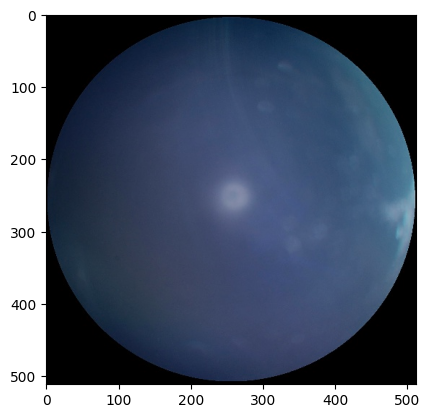

```python
# lets view a random example image
img = df_cat_all[342]
image = cv2.imread(os.path.join(image_dir, img))
plt.imshow(image)
print(image.shape)
print(img)
```

To achive better understanding of what cataracts look like, Dr. Iris creates a comparative grid showcasing images from our cataract dataset. By visualizing these examples side by side, she can observe common patterns and features associated with cataract-affected eyes. Additionally, the images will be converted to a realistic RGB color palette, enhancing their visual clarity and making them more representative of real-world conditions.

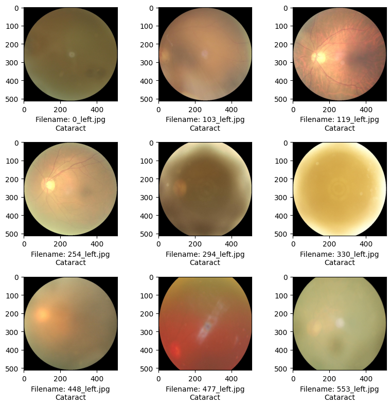

```python
plt.figure(figsize=(8,8))
for i in range(9):
    img = df_cat_all[i]
    image = cv2.imread(os.path.join(image_dir, img))

    ## convert image to RGB
    image_rgb = cv2.cvtColor(image, cv2.COLOR_BGR2RGB)

    ## subplot variables - (# of rows, # of columns, iterate through locations on grid)
    plt.subplot(3,3,i+1)
    plt.imshow(image_rgb)

    ## label with filename and diagnosis
    plt.xlabel('Filename: {}\n''Cataract'.format(df_cat_all[i]))

plt.tight_layout()
```

## Data Preperation for Normal Eyes

Next, Dr. Iris will gather a set of normal eye images for our analysis. While she previously reviewed the count of available normal images, it is important to revisit this to ensure completeness. Since she is working with data from both eyes, Dr. Iris must account for discrepancies where some encoded columns lack data for one eye, potentially leaving gaps in the full picture. To address this, she will rely on the labeling in the 'keywords' column as the primary source of truth, as it provides a comprehensive perspective by considering both eyes together.

```python
# create a new dataframe for normal eyes in the left eye and print out the number of rows

df_left_norm = df2[df2['Left-Diagnostic Keywords'].str.match('normal')]
print(len(df_left_norm))
```

```
2855
```

```python
# create a new dataframe for normal eyes in the right eye and print out the number of rows

df_rt_norm = df2[df2['Right-Diagnostic Keywords'].str.match('normal')]
print(len(df_rt_norm))
```

```
2735
```

```python
# combine dataframes into one

df_norm_all = pd.concat([df_left_norm['Left-Fundus'], df_rt_norm['Right-Fundus']], ignore_index=True)
df_norm_all
```

|  | 0 |
| --- | --- |
| 0 | 1_left.jpg |
| 1 | 8_left.jpg |
| 2 | 9_left.jpg |
| 3 | 14_left.jpg |
| 4 | 15_left.jpg |
| ... | ... |
| 5585 | 4642_right.jpg |
| 5586 | 4644_right.jpg |
| 5587 | 4660_right.jpg |
| 5588 | 4671_right.jpg |
| 5589 | 4689_right.jpg |

5590 rows × 1 columns

**dtype:** object

In total, Dr. Iris have over 5,000 images classified as 'normal,' including both left and right eye images. This is significantly more than the 572 images available in the 'cataract' category. To maintain balance in our dataset and ensure fair model training, she will randomly select an equal number of 572 'normal' images to match the size of the cataract dataset.

```python
# pick 572 normal eye images to match the number of cataract images we pulled

df_norm_random = df_norm_all.sample(n = 572)
df_norm_random.head()
```

|  | 0 |
| --- | --- |
| 1929 | 2572_left.jpg |
| 2907 | 253_right.jpg |
| 2531 | 3229_left.jpg |
| 5250 | 3167_right.jpg |
| 1608 | 1010_left.jpg |

**dtype:** object

```python
# reset the index

df_norm_random = df_norm_random.reset_index(drop=True)
df_norm_random
```

|  | 0 |
| --- | --- |
| 0 | 2572_left.jpg |
| 1 | 253_right.jpg |
| 2 | 3229_left.jpg |
| 3 | 3167_right.jpg |
| 4 | 1010_left.jpg |
| ... | ... |
| 567 | 2749_left.jpg |
| 568 | 3075_right.jpg |
| 569 | 740_left.jpg |
| 570 | 2588_left.jpg |
| 571 | 1169_right.jpg |

572 rows × 1 columns

**dtype:** object

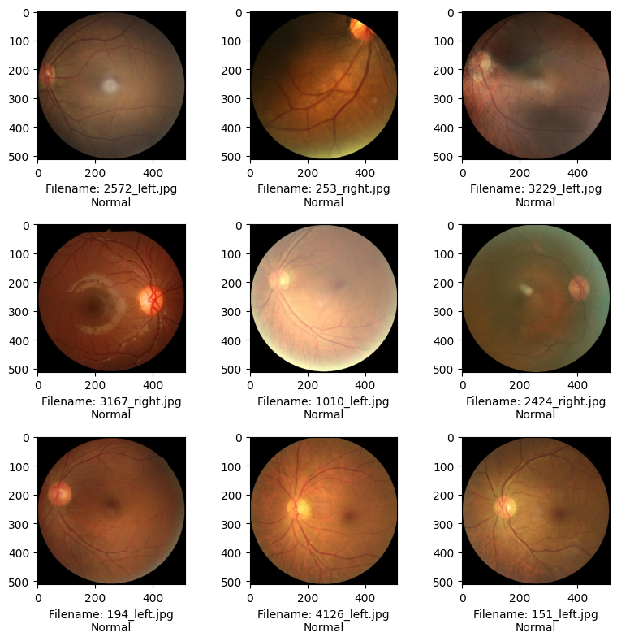

```python
# create a grid for normal eyes

plt.figure(figsize=(8,8))
for i in range(9):
    img = df_norm_random[i]
    image = cv2.imread(os.path.join(image_dir, img))

    ## convert image to RGB
    image_rgb = cv2.cvtColor(image, cv2.COLOR_BGR2RGB)

    ## subplot variables - (# of rows, # of columns, iterate through locations on grid)
    plt.subplot(3,3,i+1)
    plt.imshow(image_rgb)

    ## label with filename and diagnosis
    plt.xlabel('Filename: {}\n''Normal'.format(df_norm_random[i]))

plt.tight_layout()
```

## Model Preparation

To prepare the data for modeling, Dr. Iris needs to add category labels to the image lists. Previously, the objects df_norm_random and df_cat_all were converted into lists after appending columns. For convenience and further processing, she will convert these lists back into DataFrames.

Each image will be labeled as either 'normal' or 'cataract.' Since it was planned to use an image data generator for training, which will handle one-hot encoding automatically, she can preserve the original string labels ('normal' and 'cataract') for better readability and interpretation.

```python
df_cat_all = pd.DataFrame(df_cat_all, columns = ["filename"])

# add a new column of '1' to the dataframe
df_cat_all["label"] = "cataract"

df_cat_all.head()
```

|  | filename | label |
| --- | --- | --- |
| 0 | 0_left.jpg | cataract |
| 1 | 103_left.jpg | cataract |
| 2 | 119_left.jpg | cataract |
| 3 | 254_left.jpg | cataract |
| 4 | 294_left.jpg | cataract |

```python
df_norm_random = pd.DataFrame(df_norm_random, columns = ["filename"])

# add a new column of '1' to the dataframe
df_norm_random["label"] = "normal"

df_norm_random.head()
```

|  | filename | label |
| --- | --- | --- |
| 0 | 2572_left.jpg | normal |
| 1 | 253_right.jpg | normal |
| 2 | 3229_left.jpg | normal |
| 3 | 3167_right.jpg | normal |
| 4 | 1010_left.jpg | normal |

```python
# now that we have both cataract and normal data, lets combine them into a single dataframe

#df_combined = pd.concat([df_cat_filenames, df_norm_filenames_random], ignore_index=True)
df_combined = pd.concat([df_cat_all, df_norm_random], ignore_index=True)
df_combined
```

|  | filename | label |
| --- | --- | --- |
| 0 | 0_left.jpg | cataract |
| 1 | 103_left.jpg | cataract |
| 2 | 119_left.jpg | cataract |
| 3 | 254_left.jpg | cataract |
| 4 | 294_left.jpg | cataract |
| ... | ... | ... |
| 1139 | 2749_left.jpg | normal |
| 1140 | 3075_right.jpg | normal |
| 1141 | 740_left.jpg | normal |
| 1142 | 2588_left.jpg | normal |
| 1143 | 1169_right.jpg | normal |

1144 rows × 2 columns

Before feeding the organized set of cataract and normal images into the model, Dr. Iris needs to randomize the rows to ensure that training samples are selected randomly, promoting better generalization during model training.

When combining the datasets, appending them would result in the retention of the old index values, which will create an additional column that Dr. Iris does not need. To avoid this, she will drop the old index entirely and allow the new DataFrame to generate a fresh, sequential index, ensuring a clean and randomized dataset for training.

```python
# randomize rows of combined dataset for training

df_combined_random = df_combined.sample(frac=1).reset_index(drop=True)
df_combined_random
```

|  | filename | label |
| --- | --- | --- |
| 0 | 2118_right.jpg | cataract |
| 1 | 3385_right.jpg | normal |
| 2 | 2683_left.jpg | normal |
| 3 | 2786_left.jpg | normal |
| 4 | 2135_left.jpg | cataract |
| ... | ... | ... |
| 1139 | 2978_left.jpg | normal |
| 1140 | 2971_left.jpg | normal |
| 1141 | 2176_left.jpg | cataract |
| 1142 | 2158_left.jpg | cataract |
| 1143 | 2184_right.jpg | cataract |

1144 rows × 2 columns

```python
# pull 80% of the combined dataset and reserve it for the training data
# the data generator will automatically create a validation set for us later

df_train = df_combined_random.sample(frac=0.8,random_state=42)
df_train.reset_index(drop=True)

# exclude the 80% that was already chosen, while the remaining 20% will go into testing
df_test = df_combined_random.drop(df_train.index)
df_test.reset_index(drop=True)

print(len(df_combined_random))
print(len(df_train))
print(len(df_test))
```

```
1144
915
229
```

## Keras Preprocessing with Image Generator

Let's begin model training using Keras, a powerful deep learning framework that simplifies building, training, and deploying neural network models. With its user-friendly interface, Keras allows Dr.Iris to easily integrate CNNs, which are highly effective for image classification tasks.

She has prepared a well-structured dataframe, and with Keras's flow_from_dataframe functionality, Dr. Iris can efficiently generate augmented and scaled images directly from our dataset. Additionally, she will incorporate specific parameters to adjust the images, enhancing their variability and ensuring robust training. This combination of Keras and CNNs enables Dr. Iris to leverage advanced machine learning techniques with minimal effort.

```python
train_datagen=tf.keras.preprocessing.image.ImageDataGenerator(
            rescale=1./255.,
            validation_split=0.20,
            rotation_range=90,
            horizontal_flip=True,
            vertical_flip=True,
            shear_range=0.2,
            brightness_range=[0.3,1]
            )

# we need to rescale all of our images

test_datagen=ImageDataGenerator(rescale=1./255.)
```

```python
# convert dataframe into string type

df_train['label'] = df_train['label'].astype(str)
df_test['label'] = df_test['label'].astype(str)
```

```python
# create test, train and validation image data generators

img_size=224
train_generator=train_datagen.flow_from_dataframe(
dataframe=df_train,
directory=image_dir,
x_col="filename",
y_col="label",
subset="training",
batch_size=32,
seed=42,
shuffle=True,
class_mode='binary',
target_size=(img_size,img_size))

# validation set is created from the training set,
# we set it at 20% of the training data in the previous code

valid_generator=train_datagen.flow_from_dataframe(
dataframe=df_train,
directory=image_dir,
x_col="filename",
y_col="label",
subset="validation",
batch_size=32,
seed=42,
shuffle=True,
class_mode="binary",
target_size=(img_size,img_size))


test_generator=test_datagen.flow_from_dataframe(
dataframe=df_test,
directory=image_dir,
x_col="filename",
y_col="label",
batch_size=32,
shuffle=False,
class_mode="binary",
target_size=(img_size,img_size))
```

```
Found 732 validated image filenames belonging to 2 classes.
Found 183 validated image filenames belonging to 2 classes.
Found 229 validated image filenames belonging to 2 classes.
```

# # Image Generator Results

Now Dr. Iris decides to examine the data produced by the image generator. Using the next command, she can extract the generated data, which is divided into two separate NumPy arrays: one containing the image data and the other containing the corresponding label data. This allows her to inspect the structure and content of the preprocessed data before feeding it into the model for training.

```python
train_image_data, train_labels = next(train_generator)
train_image_data.shape
```

```
(32, 224, 224, 3)
```

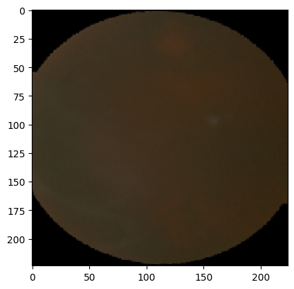

```python
# lets take a look at a single augmented image

plt.imshow(train_image_data[0], interpolation='nearest')
plt.show()
```

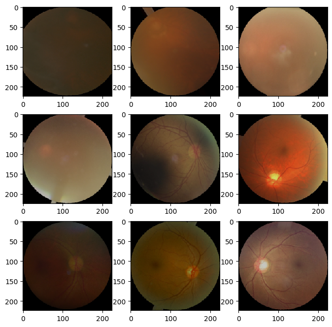

```python
# lets make a grid of the data augmented images

plt.figure(figsize=(8,8))

for i in range(9):
    plt.subplot(3, 3, i + 1)
    plt.imshow(train_image_data[i], interpolation='nearest')

plt.show()
```

# Building the Model

To build her transfer learning model, Dr. Iris utilizes the VGG16 architecture, a popular and highly effective CNN model. If a reader is interested in gaining better understanding of this architecture, Dr. Iris recommends [this](https://arxiv.org/abs/1409.1556) article. Since she is tailoring the model to the custom ODIR dataset with two output classes, she excludes the fully connected top layers of VGG16 using the include_top=False option. This allows her to customize the final layers to suit our specific classification task.

She leverages the pretrained imagenet weights for the convolutional base, which provide robust feature extraction capabilities. These weights, trained on a large-scale dataset, are optimized to detect edges, corners, and rounded areas—features that are universally relevant across image datasets. Using these pretrained filters allows Dr. Iris to speed up the training process and benefit from proven, high-quality feature maps.

To prevent overfitting, she incorporates a dropout layer, dropping 50% of the perceptrons in the final dense layer. Additionally, she uses the ADAM optimizer, an advanced gradient descent algorithm, to efficiently optimize our model during training.

```python
# get VGG16 base model
vgg16 = keras.applications.vgg16.VGG16(input_shape=(224, 224, 3),
                                       weights='imagenet',
                                       include_top=False)

# add new dense layers at the top
x = keras.layers.Flatten()(vgg16.output)
x = keras.layers.Dense(1024, activation='relu')(x)
x = keras.layers.Dropout(0.5)(x)
x = keras.layers.Dense(128, activation='relu')(x)

## remember we are using 2 outputs only
predictions = keras.layers.Dense(1, activation='sigmoid')(x)

# define and compile model
model = keras.Model(inputs=vgg16.inputs, outputs=predictions)
for layer in vgg16.layers:
    layer.trainable = False

model.compile(optimizer='adam',
              loss='binary_crossentropy',
              metrics=['accuracy', 'Recall', Precision(), AUC(name='auc')])
```

For her model, Dr. Iris chose to implement both checkpointing and early stopping to enhance the training process and optimize model performance. A checkpoint allows her to monitor the model's accuracy during training and perform specific tasks when certain conditions are met. In this case, the checkpoint is configured to save the model as a file whenever it achieves its best validation accuracy, ensuring that the optimal version of the model is preserved.

Early stopping is used to monitor the model's accuracy over epochs based on a 'patience' parameter. If there is no improvement in accuracy within the specified number of consecutive epochs, the training process is automatically halted. This prevents unnecessary computation and reduces the risk of overfitting by stopping the training when further epochs are unlikely to yield significant performance gains. Together, these techniques ensure an efficient and effective training process while preserving the best-performing model for later use.

```python
checkpoint = ModelCheckpoint(
    "vgg16_1.keras",
    monitor='val_accuracy',
    verbose=1,
    save_best_only=True,
    save_weights_only=False,
    mode='auto'
)


early = EarlyStopping(
    monitor='val_accuracy',
    min_delta=0,
    patience=3,
    verbose=1,
    mode='auto'
)
```

The steps_per_epoch parameter determines how many batches of samples are processed to complete one full epoch during model training. This value depends on the batch size, which is defined when initializing the training data.

The total number of steps per epoch is typically calculated as the total number of samples in the training set divided by the batch size, ensuring all data is seen once per epoch. This parameter is essential for controlling the training process and aligning it with the size of your dataset and batch configuration.

```python
batch_size = 32
n_spe = train_generator.samples // batch_size # steps per epoch
n_val_steps = valid_generator.samples // batch_size # number of validation steps
n_epochs = 30

print(n_spe,n_val_steps)
```

```
22 5
```

```python
# train the model

hist = model.fit(
    train_generator,
    steps_per_epoch=n_spe,
    validation_data=valid_generator,
    validation_steps=n_val_steps,
    epochs=n_epochs,
    shuffle=True,
    callbacks=[checkpoint, early]
)
```

```
22/22 ━━━━━━━━━━━━━━━━━━━━ 0s 355ms/step - Recall: 0.8372 - accuracy: 0.7877 - auc: 0.8944 - loss: 0.4276 - precision_1: 0.7755
Epoch 1: val_accuracy improved from -inf to 0.85000, saving model to vgg16_1.keras
22/22 ━━━━━━━━━━━━━━━━━━━━ 21s 703ms/step - Recall: 0.8353 - accuracy: 0.7882 - auc: 0.8940 - loss: 0.4277 - precision_1: 0.7771 - val_Recall: 0.9737 - val_accuracy: 0.8500 - val_auc: 0.9521 - val_loss: 0.3602 - val_precision_1: 0.7708
 1/22 ━━━━━━━━━━━━━━━━━━━━ 3s 168ms/step - Recall: 0.7895 - accuracy: 0.8438 - auc: 0.8381 - loss: 0.5318 - precision_1: 0.9375
Epoch 2: val_accuracy did not improve from 0.85000
22/22 ━━━━━━━━━━━━━━━━━━━━ 0s 6ms/step - Recall: 0.7895 - accuracy: 0.8438 - auc: 0.8381 - loss: 0.5318 - precision_1: 0.9375 - val_Recall: 1.0000 - val_accuracy: 0.8261 - val_auc: 0.9127 - val_loss: 0.4717 - val_precision_1: 0.6923
22/22 ━━━━━━━━━━━━━━━━━━━━ 0s 389ms/step - Recall: 0.7780 - accuracy: 0.7618 - auc: 0.8674 - loss: 0.4683 - precision_1: 0.7855
Epoch 3: val_accuracy did not improve from 0.85000
22/22 ━━━━━━━━━━━━━━━━━━━━ 14s 530ms/step - Recall: 0.7776 - accuracy: 0.7631 - auc: 0.8682 - loss: 0.4665 - precision_1: 0.7868 - val_Recall: 0.8553 - val_accuracy: 0.8062 - val_auc: 0.9253 - val_loss: 0.3822 - val_precision_1: 0.7647
 1/22 ━━━━━━━━━━━━━━━━━━━━ 2s 118ms/step - Recall: 0.9500 - accuracy: 0.9062 - auc: 0.9667 - loss: 0.3442 - precision_1: 0.9048
Epoch 4: val_accuracy improved from 0.85000 to 0.91304, saving model to vgg16_1.keras
22/22 ━━━━━━━━━━━━━━━━━━━━ 2s 102ms/step - Recall: 0.9500 - accuracy: 0.9062 - auc: 0.9667 - loss: 0.3442 - precision_1: 0.9048 - val_Recall: 1.0000 - val_accuracy: 0.9130 - val_auc: 0.9921 - val_loss: 0.3104 - val_precision_1: 0.8182
22/22 ━━━━━━━━━━━━━━━━━━━━ 0s 438ms/step - Recall: 0.8194 - accuracy: 0.7975 - auc: 0.8924 - loss: 0.4200 - precision_1: 0.7981
Epoch 5: val_accuracy did not improve from 0.91304
22/22 ━━━━━━━━━━━━━━━━━━━━ 15s 550ms/step - Recall: 0.8192 - accuracy: 0.7986 - auc: 0.8931 - loss: 0.4180 - precision_1: 0.7997 - val_Recall: 0.8611 - val_accuracy: 0.8687 - val_auc: 0.9513 - val_loss: 0.2943 - val_precision_1: 0.8493
 1/22 ━━━━━━━━━━━━━━━━━━━━ 2s 119ms/step - Recall: 0.9000 - accuracy: 0.8438 - auc: 0.8708 - loss: 0.4180 - precision_1: 0.8571
Epoch 6: val_accuracy did not improve from 0.91304
22/22 ━━━━━━━━━━━━━━━━━━━━ 0s 12ms/step - Recall: 0.9000 - accuracy: 0.8438 - auc: 0.8708 - loss: 0.4180 - precision_1: 0.8571 - val_Recall: 0.9231 - val_accuracy: 0.8261 - val_auc: 0.9000 - val_loss: 0.3758 - val_precision_1: 0.8000
22/22 ━━━━━━━━━━━━━━━━━━━━ 0s 445ms/step - Recall: 0.8168 - accuracy: 0.8394 - auc: 0.9287 - loss: 0.3388 - precision_1: 0.8716
Epoch 7: val_accuracy did not improve from 0.91304
22/22 ━━━━━━━━━━━━━━━━━━━━ 15s 556ms/step - Recall: 0.8168 - accuracy: 0.8392 - auc: 0.9283 - loss: 0.3395 - precision_1: 0.8710 - val_Recall: 0.8767 - val_accuracy: 0.8813 - val_auc: 0.9442 - val_loss: 0.3106 - val_precision_1: 0.8649
Epoch 7: early stopping
```

Dr. Iris observes that the model stops early as the results do not show any improvement. She saves the model and visualizes the results.

```python
# load saved model

model = load_model('./vgg16_1.keras')
```

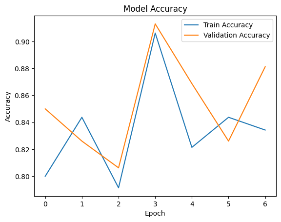

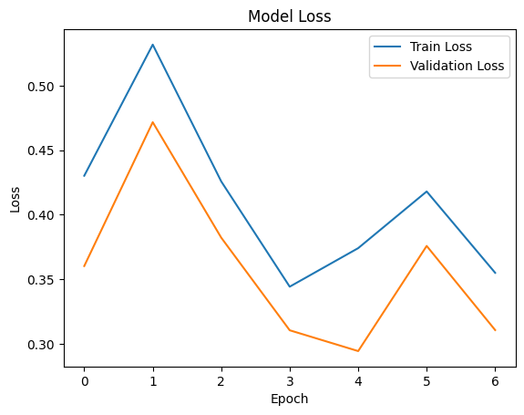

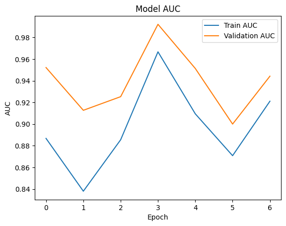

```python
# Plot Accuracy
plt.plot(hist.history["accuracy"], label="Train Accuracy")
plt.plot(hist.history["val_accuracy"], label="Validation Accuracy")
plt.title("Model Accuracy")
plt.ylabel("Accuracy")
plt.xlabel("Epoch")
plt.legend()
plt.show()

# Plot Loss
plt.plot(hist.history['loss'], label="Train Loss")
plt.plot(hist.history['val_loss'], label="Validation Loss")
plt.title("Model Loss")
plt.ylabel("Loss")
plt.xlabel("Epoch")
plt.legend()
plt.show()

# Plot Recall
if 'recall' in hist.history:
    plt.plot(hist.history['recall'], label="Train Recall")
    plt.plot(hist.history['val_recall'], label="Validation Recall")
    plt.title("Model Recall")
    plt.ylabel("Recall")
    plt.xlabel("Epoch")
    plt.legend()
    plt.show()

# Plot AUC
if 'auc' in hist.history:
    plt.plot(hist.history['auc'], label="Train AUC")
    plt.plot(hist.history['val_auc'], label="Validation AUC")
    plt.title("Model AUC")
    plt.ylabel("AUC")
    plt.xlabel("Epoch")
    plt.legend()
    plt.show()
```

# Making Predicitions

Using predict_generator, Dr. Iris can generate predictions for the test dataset by feeding batches of image data into the model through a generator. Before making predictions, the test generator is reset to ensure that no leftover image data from previous iterations is carried over. The output of the predictions consists of categorical labels, where 0 represents "Cataract" and 1 represents "Normal." It is important to note that the predictions output numerical labels rather than image data, providing classification results for the test images

```
8/8 ━━━━━━━━━━━━━━━━━━━━ 1s 123ms/step
```

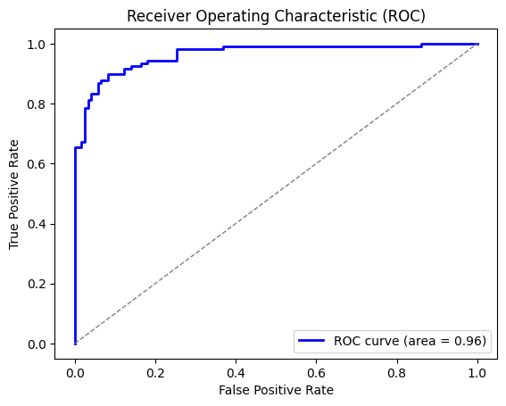

```python
# Generate predictions and true labels
y_pred_prob = model.predict(test_generator)  # Predicted probabilities
y_true = test_generator.labels  # True labels from the generator

# Compute ROC curve
fpr, tpr, thresholds = roc_curve(y_true, y_pred_prob)
roc_auc = auc(fpr, tpr)

# Plot ROC Curve
plt.figure()
plt.plot(fpr, tpr, color='blue', lw=2, label=f'ROC curve (area = {roc_auc:.2f})')
plt.plot([0, 1], [0, 1], color='gray', lw=1, linestyle='--')
plt.title('Receiver Operating Characteristic (ROC)')
plt.xlabel('False Positive Rate')
plt.ylabel('True Positive Rate')
plt.legend(loc="lower right")
plt.show()
```

Dr. Iris sees that the AUC ROC metric is 0.96, which is a pretty good results. LEt's now do the predictions

```python
steps = math.ceil(test_generator.samples / batch_size)

pred = model.predict(test_generator, verbose=1, steps=steps)
```

```
8/8 ━━━━━━━━━━━━━━━━━━━━ 1s 123ms/step
```

```python
# convert the data into 1s and 0s for simple classification

predicted_class_idx=np.argmax(pred,axis=1)

#print the same 10 rows

print(predicted_class_idx[0:10])
print(len(predicted_class_idx))
```

```
[0 0 0 0 0 0 0 0 0 0]
229
```

```python
# Reset the generator (not always necessary, but good practice)
test_generator.reset()

# Evaluate the model
results = model.evaluate(test_generator, verbose=1)

# Print results
print(f"Test Loss: {results[0]:.4f}")
print(f"Test Accuracy: {results[1]:.4f}")
print(f"Test Recall: {results[2]:.4f}")
print(f"Test AUC: {results[3]:.4f}")
```

[output not shown]

```python
# instead of 1s and 0s now, convert one-hot category labels to text labels

valid_generator.class_indices.items()
```

```
dict_items([('cataract', 0), ('normal', 1)])
```

Here, Dr. Iris uses the training label string names, "Cataract" and "Normal," to convert the one-hot encoded predicted class labels back into their corresponding string names. These lines of code map the predicted numerical values to their respective category names and store them in the predicted_labels variable, ensuring the output is human-readable and aligned with the original label categories.

```python
valid_labels = dict((value,key) for key,value in valid_generator.class_indices.items())
pred_labels = [valid_labels[key] for key in predicted_class_idx]
pred_labels[1:10]
```

```
['cataract',
 'cataract',
 'cataract',
 'cataract',
 'cataract',
 'cataract',
 'cataract',
 'cataract',
 'cataract']
```

```python
# create a new dataframe with filename and prediction

filenames = test_generator.filenames
prediction_df = pd.DataFrame({'Filename': filenames,'Prediction': pred_labels})
prediction_df.head()
```

|  | Filename | Prediction |
| --- | --- | --- |
| 0 | 3385_right.jpg | cataract |
| 1 | 1452_left.jpg | cataract |
| 2 | 1415_right.jpg | cataract |
| 3 | 2560_left.jpg | cataract |
| 4 | 2233_right.jpg | cataract |

```python
prediction_df.iloc[35]
```

|  | 35 |
| --- | --- |
| Filename | 2135_left.jpg |
| Prediction | cataract |

**dtype:** object

```python
print(test_generator.filenames[35])
print(test_generator.labels[35])
```

```
2135_left.jpg
0
```

*Now* that Dr. Iris has verified that the test data and predictions are properly aligned, she can list all predictions and compare them to the actual test labels. This example is conducted using a small sample of the test dataset (just 10 samples) for simplicity and clarity.

```python
test_file_names=test_generator.filenames  # sequential list of name of test files of each sample
test_labels=test_generator.labels # is a sequential list  of test labels for each image sample
class_dict= test_generator.class_indices # a dictionary where key is the class name and value is the label for the class

print (class_dict)

new_dict={}

for key in class_dict: # set key in new_dict to value in class_dict and value in new_dict to key in class_dict
    value = class_dict[key]
    new_dict[value] = key

print('  RESULT  PREDICT      TRUE CLASS       FILENAME ' )

for i, p in enumerate(pred[:10]):
    pred_index=np.argmax(p) # get the index that has the highest probability
    pred_class=new_dict[pred_index]  # find the predicted class based on the index
    true_class=new_dict[test_labels[i]] # use the test label to get the true class of the test file
    file=test_file_names[i]

    if true_class == pred_class:
        result = "Correct"
    else:
        result = "Wrong  "


    print(f' {result}   {pred_class}    {true_class}      {file}')
```

```
{'cataract': 0, 'normal': 1}
  RESULT  PREDICT      TRUE CLASS       FILENAME
 Wrong     cataract    normal      3385_right.jpg
 Correct   cataract    cataract      1452_left.jpg
 Correct   cataract    cataract      1415_right.jpg
 Wrong     cataract    normal      2560_left.jpg
 Correct   cataract    cataract      2233_right.jpg
 Correct   cataract    cataract      2117_left.jpg
 Wrong     cataract    normal      3359_right.jpg
 Correct   cataract    cataract      1084_right.jpg
 Correct   cataract    cataract      2181_right.jpg
 Correct   cataract    cataract      2118_right.jpg
```

Here Dr. Iris has retrieve a batch of test images and their corresponding labels from the test generator, then examine a specific sample by printing its filename, true label, and predicted label. It ensures the test data, labels, and predictions are correctly aligned for validation and debugging.

```python
test_image_data, test_labels = next(test_generator)

print(test_image_data.shape)
print(test_labels.shape)

z = 0
test_file_names=test_generator.filenames[z]
print(test_file_names)

test_labels_example=test_generator.labels[z]
print(test_labels_example)

pred_labels[z]
```

```
(32, 224, 224, 3)
(32,)
3385_right.jpg
1
```

```
'cataract'
```

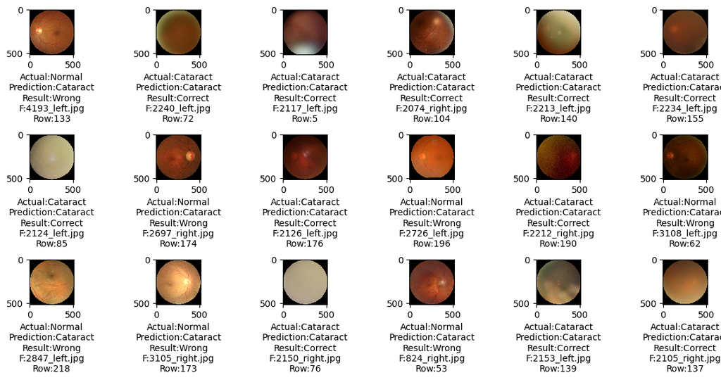

```python
# plot our comparison grid

plt.figure(figsize=(12,6))
for i in range(18):
    sample = random.choice(range(test_generator.samples))

    img = test_generator.filenames[sample]
    image = cv2.imread(os.path.join(image_dir, img))
    image_rgb = cv2.cvtColor(image, cv2.COLOR_BGR2RGB)
    category = test_generator.labels[sample]
    pred_category = pred_labels[sample]

    if category== 1:
        label = "Normal"
    else:
        label = "Cataract"

    if pred_category== "normal":
        pred_label = "Normal"
    else:
        pred_label = "Cataract"

    if label == pred_label:
        result = "Correct"
    else:
        result = "Wrong"


    plt.subplot(3,6,i+1)
    plt.imshow(image_rgb, interpolation='nearest')
    plt.xlabel("Actual:{}\nPrediction:{}\nResult:{}\nF:{}\nRow:{}".format(label,
                                                                          pred_label,
                                                                          result,
                                                                          test_generator.filenames[sample],
                                                                          sample))
plt.tight_layout()
```

# Confusion matrix

Dr. Iris creates a confusion matrix to gain deeper understanding of the wrong answers distribution.

```python
cm = confusion_matrix(test_generator.labels, predicted_class_idx)
print('Confusion Matrix')
cm
```

```
Confusion Matrix
```

[output not shown]

```python
def plot_confusion_matrix(cm, classes,
                        normalize=False,
                        title='Confusion matrix',
                        cmap=plt.cm.Blues):

    plt.imshow(cm, interpolation='nearest', cmap=cmap)
    plt.title(title)
    plt.colorbar()
    tick_marks = np.arange(len(classes))
    plt.xticks(tick_marks, classes, rotation=45)
    plt.yticks(tick_marks, classes)

    if normalize:
        cm = cm.astype('float') / cm.sum(axis=1)[:, np.newaxis]
        print("Normalized confusion matrix")
    else:
        print('Confusion matrix, without normalization')

    print(cm)

    thresh = cm.max() / 2.
    for i, j in itertools.product(range(cm.shape[0]), range(cm.shape[1])):
        plt.text(j, i, cm[i, j],
            horizontalalignment="center",
            color="white" if cm[i, j] > thresh else "black")

    plt.tight_layout()
    plt.ylabel('True label')
    plt.xlabel('Predicted label')
cm_plot_labels = ['cataract','normal']
```

[output not shown]

[figure not shown]

```python
plot_confusion_matrix(cm=cm, classes=cm_plot_labels, title='Confusion Matrix')
```